# Coursework Report

*N* removed NAs: 5

*N* removed <18: 15

**Correct typo age:** 23

*N* total clean: 148

| Group | *N* | *M*<sub>age</sub> | % green |
| --- | --- | --- | --- |
| Control | 76 | 20.84 | 39.91 |
| Experim | 72 | 20.76 | 53.70 |

| Gender | *N* | *M*<sub>age</sub> | % green |
| --- | --- | --- | --- |
| Female | 74 | 20.70 | 46.40 |
| Male | 49 | 21.12 | 48.98 |
| Other | 25 | 20.48 | 42.67 |

**Main analysis results**

**car:**  
χ<sup>2</sup>(1) = 1.63, *p* = .201

**cleaner:**  
χ<sup>2</sup>(1) = 3.79, *p* = .052

**dishwasher:**  
χ<sup>2</sup>(1) = 1.95, *p* = .163

[interactive chart not shown]

[figure not shown]

[interactive chart not shown]

# Coursework Report

Analysing Data, Spring 2020

# Methods

## Participants

A total number of 168 participants took part in this study. However due to inappropriate ages (Age < 18 years-old), and 5 participants not submitting their age, a total of 20 participants’ data was removed. Therefore, 148 participants’ data (444 responses, with every participant making three recorded decisions) was used. Consisting of a total of 33.11% male participants, 50% female, and 16.89% who classified as ‘other’. The general ages of participants varied with Mean<sub>age</sub> = 20.8, and SD<sub>age</sub> = 1.82 with limits of Min<sub>age</sub> = 18 and Max<sub>age</sub> = 27. The variation of age within gender categories can be seen in Table 1 below, while the distribution of genders across conditions is seen in Table 2.

Table 1. Gender and Age Demographic

| Gender | Responses | M<sub>Age</sub> | SD<sub>Age</sub> |
| --- | --- | --- | --- |
| female | 222 | 20.70 | 1.73 |
| male | 147 | 21.12 | 2.12 |
| other | 75 | 20.48 | 1.34 |

Table 2. Gender Distribution across Conditions

| Condition | Gender | Responses |
| --- | --- | --- |
| Neutral Control Story | female | 117 |
| Neutral Control Story | male | 72 |
| Neutral Control Story | other | 39 |
| High-Status Story | female | 105 |
| High-Status Story | male | 75 |
| High-Status Story | other | 36 |

Worth noting is the difference in numbers of participants per condition; 76 in the Control, with 72 in the Status-Motives Condition.

## Design

This study was a replica study of that carried out by Griskevicius et al. (2010) in attempt to answer the question of why people choose to buy ‘green’ products, and more specifically, whether buying ‘green’ products is related to status motives.

In order to do this, two between-subjects motive conditions were used; a High-Status and Control Condition. Status-motives were ensured by a status-eliciting story (Griskevicius et al., 2009). For both of these conditions, participants were asked to display their preferences between identically priced ‘luxury’ or ‘green’ types of car, dishwasher and household cleaner.

We predicted that in the control condition, due to being more desirable, the ‘luxury’ version would be chosen more while for the high-status motive condition, we predicted that green products would be chosen more.

Our independent variable was the “Condition” in which a participant took part in the study ie. whether they read the Neutral Control Story, eliciting no motives, or they read the High-Status Story. The dependent variable was the, categorical, “Choice” made by the participant for a particular product (“green” versus “luxury”).

With our operational hypothesis being that participants in the High-Status Condition would choose products to be “green” more often than those in the Control Condition, the distinct categorical nature of the variables meant that we needed to use a χ<sup>2</sup>-test, with condition as the predictor and the preference made (ie. choice) as the outcome. The test will see if the change in ‘green’ choices from the control condition to the experimental condition is significant, and therefore whether there really is a relationship between status-motives and choosing green products.

# Results

Given that our expectation was that more green choices would be made in the status-motives condition, the trend in our results showed us to be correct. Across all three products the status motives condition elicited greater numbers of decisions for the green products, distributions of which can be seen in table 3.1 and 3.2, below.

Table 3.1 Distribution of Choices made for each Product in the Control Condition, for the Neutral Story

| Product | Choice | N | % |
| --- | --- | --- | --- |
| car | luxury | 49 | 64.47% |
| car | green | 27 | 35.53% |
| dishwasher | luxury | 36 | 47.37% |
| dishwasher | green | 40 | 52.63% |
| cleaner | luxury | 52 | 68.42% |
| cleaner | green | 24 | 31.58% |

Table 3.2 Distribution of Choices made for each Product in the High-Status Condition, for the High-Status Story

| Product | Choice | N | % |
| --- | --- | --- | --- |
| car | luxury | 38 | 52.78% |
| car | green | 34 | 47.22% |
| dishwasher | luxury | 25 | 34.72% |
| dishwasher | green | 47 | 65.28% |
| cleaner | luxury | 37 | 51.39% |
| cleaner | green | 35 | 48.61% |

Interestingly, the dishwasher showed majority green decisions for both control and high-status story conditions, with 52.63% green decisions made for the control condition and 65.28% green choices made for the experimental condition (compared to 47.37% and 34.72% ‘luxury’ choices made in the control and experimental conditions, respectively).

We can see that the story-type condition did affect the type of product chosen; more green products were chosen when status-motives were elicited, demonstrated in Figure 1.

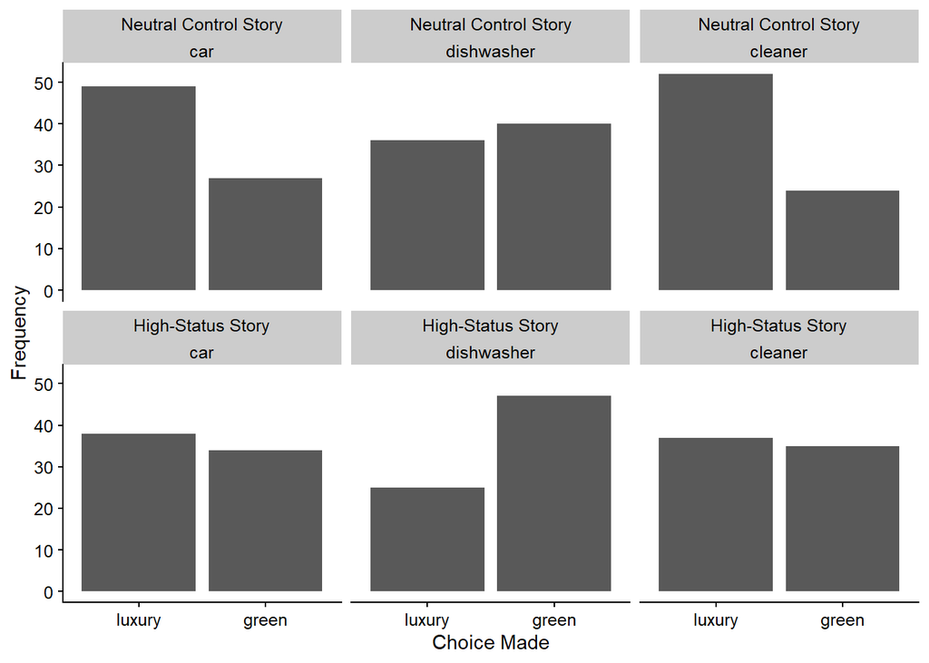

Figure 1. Graphs to show Variation in Choices made for Products across the Conditions

In the control condition: 27 participants chose the “green” car, whereas for the high-status condition, 34 chose it, χ<sup>2</sup>(1, N = 72) = 1.63, p = 0.201. Similarly, despite an already higher number of green dishwasher choices there was a change seen; in the control condition 40 participants chose the “green” version, while 47 “green” choices were made in the high-status condition, χ<sup>2</sup>(1, N = 72) = 1.95, p = 0.163. Finally, for the cleaner, a similar change was seen between conditions with 24 and 35 green choices made for the control and high-status conditions respectively, χ<sup>2</sup>(1, N = 72), p = 0.052.

While none of the above results are considered significant, the general changes in green choices made across conditions shows us that 91 “green” choices were made in the control condition while there were 116 “green” choices across high-status condition, χ<sup>2</sup>(1, N = 216), p = 0.005 which is significant.

# Discussion

As a replica study of Griskevicius’ (2010), the same question was asked; does eliciting status motives in participants increase the number of ‘green’ choices they make. As in Griskevicius’ study, our results showed that status-motives elicit an increase in green product choices, as can be seen clearly, above, in Figure 1. Interestingly, although there was an overall increase in green purchase-intention choices, there was no statistically significant change in green choices for any individual product. When the data of all three products was combined however, there was a statistically significant increase in the number of green choices made in the status-motives condition.

This result is important because it clearly indicates that factors other than a desire to be eco-friendly influence eco-friendly purchase-intention. That our results support the original conclusion (Griskevicius et al., 2010) is also important; the same effect being produced demonstrates the validity of the result. This is especially the case as the research was carried out in different locations with different populations, and produced different data, but still exhibited the same trends; both studies reported that status-motives drove a statistically-significant increase in all green choices across all products, but that this was not the case for any individual product.

It is interesting to reflect on Griskevicius’ study (2010) and our own results in relation to other purchase-intention research. Sundie et al. (2011) investigated conspicuous consumption (defined as self-presentation superseding desire for bargains), and how it relates to “short term mating” goals. They discovered that those who desire short term intimacy are influenced by conspicuous consumption or consume conspicuously themselves. Though un-related to green product choices, it is apparent from this that perceived self-image can be a key factor in influencing what people choose to buy. General research into purchasing intention is extensive. Joshi & Rahman (2015) conducted a literary-analysis of over 100 research papers about green purchase-intentions; referring, for example, to findings indicating that “Environmental attitude” is “Unrelated” to purchasing intention, and other findings demonstrating that cost is an influencing factor in green purchase-intentions. It is clear that some factors affect purchase-intention more than others. Other research (Hartmann & Apaolaza-Ibáñez, 2012) found that “exposure to natural imagery enhances the influence of environmental concern on purchase intention”. Our research demonstrates, however, that direct environmental context (eg. nature experience) is not necessary to encourage eco-purchase. Associating eco-purchases with perceived status-gain (status-motive), with no direct environmental or eco context, is enough to have a positive influence on green purchase-intention.

It is interesting to consider other possible explanations for the increase in purchase-intention for green products. Previous research has demonstrated that the primer ‘story’ successfully elicits status-motives (Griskevicius et al., 2009). Hypothetically, could it be that this effect on participants is a result of their empathising with the character, and, therefore, will not have a lasting effect; that the effect is fabricated and not ‘real’? Once outside the study, and beyond the exercise, the participant might revert to their own, unaffected, purchase-intention. Whilst there may have been a pre-existing green purchase-intention, it is possible that the green purchase-intention response would not have occurred without the stimulus of the story/question – a ‘question-induced’ response (Posavac, 2015, p. 220). It is possible that the story could be eliciting another, quite different, cognitive response which influences/determines green purchase-intentions; the participants were not asked about their understanding of the story or what it meant to them or their attitudes to green-products prior to reading the story. Future research is necessary to explore these ideas. These ideas do not alter our conclusion, and as our study replicated the story-method exactly (Griskevicius et al., 2010) it did not address them.

There are a number of limitations to this study, each of which will need further research to understand fully. The age-range, and number, of participants in our study (younger millennials) are not large enough to indicate generalised conclusions about status-motives affecting purchase-intention of eco-products and are not narrow enough to be truly specific. The study does however, give a useful indication of how this portion of the, fast-becoming, central consumer-group (Gapper, 2018) intends to spend its money, and provides useful insight into how the group in our study make their green purchase decisions. A further limitation is that participants were given choices between identically priced products, and only asked to express a preference (ie. intention); there was no follow up exercise or research into assessing cost impact, or actual purchase-behaviour. We know that people do not always follow through with their intentions (Rogers et al., 2015) and it is clear that the lack of cost variation means the study cannot provide any insight into price driven decision-making, or how strong the desire for eco-products is within that context. There are likely to be many factors in purchases driven by status motive that have not been considered by this study.

Building on the finding that eco-product desire tends to increase with status-motives, further research could investigate how this affects certain groups of individuals. For example, other research found that married mothers, with at least one child, are most likely to spend more on eco-friendly products (Laroche et al., 2001); is she doing so to protect her child, or because she believes that it increases her status? The relationship between status-motives and cost could also be studied, to ascertain the strength of the elicited desire for eco-friendliness in relation to perceived cost value. Changing established purchase-behaviours (in favour of green) is also interesting; research has found that 26% Americans stay with the same bank more than 20 years (Dixon, 2017) - combining this with our research and the knowledge that older people are less willing to change (Chamorro-Premuzic, 2014), that people are strongly influenced by those closest to them, and that product familiarity is an influencing factor (eg. Lautiainen, 2015), this could provide a foundation for further study into specific group and socio-demographic green purchase-intentions. The scope of the research could extend from inexpensive ‘everyday’ household purchases to more significant, and more expensive, items such as electric cars. Following from this, research could inform on the differences between product types; are there some specific products that have statistically significant increases in eco-choices when status-motives are elicited, and others where this factor only has a marginal impact? Finally, further research could attempt to find the relationship between status-motives and purchase-behaviour to see if intent does translate into action.

To conclude, this research has reinforced the idea that eliciting status-motives in participants increases the number of green product choices made. This is an important reiteration of Griskevicius’ (2010) research, increasing the reliability of the result and corroborating their conclusion. In showing that status-motives significantly increase the total number of green-products chosen by participants the research indicates that status motives can be used as a predictor of eco-purchase-intentions. This result has immediate useful applications – helping to inform marketeers in their use of status motivations to encourage consumers to make more eco-friendly purchase choices, for example, or facilitating environmental organisations in encouraging more general eco-friendly behaviours. This study is an important building block in our understanding of the motivations (in this case status)

behind consumer eco purchase-intentions, and also in how those intentions can, potentially, be influenced.

# References

Chamorro-Premuzic, T. (2014, October 11). Why Are Older People More Conservative? Psychology Today. http://www.psychologytoday.com/blog/mr-personality/201410/why-are-older-people-more-conservative

Dixon, A. (2017, October 23). Survey Finds Americans Stay Married To Banks For Many Many Years | Bankrate.com. Bankrate. https://www.bankrate.com/banking/best-banks-consumer-survey/

Gapper, J. (2018, June 6). How millennials became the world’s most powerful consumers. Financial Times. https://www.ft.com/content/194cd1c8-6583-11e8-a39d-4df188287fff

Griskevicius, V., Tybur, J. M., Gangestad, S. W., Perea, E. F., Shapiro, J. R., & Kenrick, D. T. (2009). Aggress to impress: Hostility as an evolved context-dependent strategy. Journal of Personality and Social Psychology, 96(5), 980–994. https://doi.org/10.1037/a0013907

Griskevicius, V., Tybur, J. M., & Van den Bergh, B. (2010). Going green to be seen: Status, reputation, and conspicuous conservation. Journal of Personality and Social Psychology, 98(3), 392–404. https://doi.org/10.1037/a0017346

Hartmann, P., & Apaolaza-Ibáñez, V. (2012). Consumer attitude and purchase intention toward green energy brands: The roles of psychological benefits and environmental concern. Journal of Business Research, 65(9), 1254–1263. https://doi.org/10.1016/j.jbusres.2011.11.001

Joshi, Y., & Rahman, Z. (2015). Factors Affecting Green Purchase Behaviour and Future Research Directions. International Strategic Management Review, 3(1), 128–143. https://doi.org/10.1016/j.ism.2015.04.001

Laroche, M., Bergeron, J., & Barbaro‐Forleo, G. (2001). Targeting consumers who are willing to pay more for environmentally friendly products. Journal of Consumer Marketing, 18(6), 503–520. https://doi.org/10.1108/EUM0000000006155

Lautiainen, T. (2015). Factors affecting consumers’ buying decision in the selection of a coffee brand. 40.

Posavac, S. S. (2015). Cracking the Code: Leveraging Consumer Psychology to Drive Profitability: Leveraging Consumer Psychology to Drive Profitability. Routledge.

Rogers, T., Milkman, K. L., John, L. K., & Norton, M. I. (2015). Beyond good intentions: Prompting people to make plans improves follow-through on important tasks. Behavioral Science & Policy, 1(2), 33–41. https://doi.org/10.1353/bsp.2015.0011

Sundie, J. M., Kenrick, D. T., Griskevicius, V., Tybur, J. M., Vohs, K. D., & Beal, D. J. (2011). Peacocks, Porsches, and Thorstein Veblen: Conspicuous consumption as a sexual signaling system. Journal of Personality and Social Psychology, 100(4), 664–680. https://doi.org/10.1037/a0021669